# COMPSCIX 415.2 Homework 9/Final

Shan Valleru

3/31/2019

My Github repository for my assignments can be found at this URL: https://github.com/svalleru/compscix-415-2-assignments

```r
library(tidyverse)
library(broom)
```

# Exercise 1 - Sampling Distributions, Functions and For Loops

```r
# sample size
samp_size <- 100
# set the rate parameter
samp_rate <- 1/10000

# take sample
rexp(n = samp_size, rate = samp_rate)
```

```
##   [1]  1317.13360  3707.77138 13166.50348  7886.37968 21108.69902
##   [6]  1424.55533 22536.35468  7703.89963  2045.27190  8347.56114
##  [11] 14526.70291 19061.71659  7830.96737  3158.42168 34071.07182
##  [16]  2140.45618  5956.21374  8338.21027  5957.66312  1730.39767
##  [21]  7772.39222 22682.06291   453.14554  6840.72426  1221.51090
##  [26] 10239.13772  2116.53451  1661.51135  4450.99024 40763.82166
##  [31]  8605.58707 15485.63367  6320.98699   208.66860 11866.88577
##  [36]  3463.08993   821.97503 12472.59852   775.53320 13164.01637
##  [41]  7224.74095  4858.54238    84.26184  5597.38945  4799.64129
##  [46]  8168.67118  4656.66006   292.74777  6376.98781   397.06254
##  [51]  4152.68261 11355.28336  4008.54676  9438.23992  4557.40036
##  [56] 11037.48472  2900.31986  2632.40403  4502.28314  1974.15102
##  [61]  1922.14147 26401.66698 10516.49448   716.35065  5825.56366
##  [66] 29618.71676 13041.34148 15104.07740 17985.36664  1386.00868
##  [71]  7632.76574  8429.42895   366.40846  6015.65628  6416.15890
##  [76] 34912.77491 23691.88418  4912.55313 12092.09061  5414.88230
##  [81] 16272.65125 18957.61080  4240.90419  2648.45448   796.96347
##  [86]  1171.44746  6679.22931  6720.30559  7699.40173 21357.65085
##  [91]  5042.73634 12817.95729  1901.37380  1898.46439  6886.80983
##  [96]  7379.16048  6877.19059 21969.23660 27253.16783   818.26288
```

**STEP 1**

Write an R function that does the following:

- Takes a sample of size `samp_size` from this exponential distribution (`samp_size` is an input parameter for the function)
- Calculates the mean of that sample
- Calculates the standard deviation of that sample
- Returns the calculated mean and standard deviation as a list

```r
samp_fun <- function(samp_size, samp_rate) {

  sample <- rexp(n = samp_size, rate = samp_rate)
  samp_avg <- mean(sample)
  samp_std_dev <- sd(sample)

  stats <- list(samp_avg = samp_avg, samp_std_dev = samp_std_dev)
  return(stats)
}
```

**STEP 2**

Then write a loop that does this:

Runs the above function 1000 times, with `samp_size = 50` and `samp_rate = 1/10000` Saves all of the sample means in a vector called `sample_means`, and all of the sample standard deviations in a vector called `sample_sds`

```r
iterations <- 1000
samp_size <- 50
samp_rate <- 1/1000

sample_means <- sample_sds <- c()

for (i in 1:iterations) {
  stats <- samp_fun(samp_size, samp_rate)
  sample_means[i] <- stats$samp_avg
  sample_sds[i] <- stats$samp_std_dev
}
```

**STEP 3**

Then

plot your sample means as a histogram output the standard deviation of your sample means calculate the theoretical standard error (σ=10000, n = sample size) calculate the mean of the sample standard deviations and use this to calculate the empirical standard error

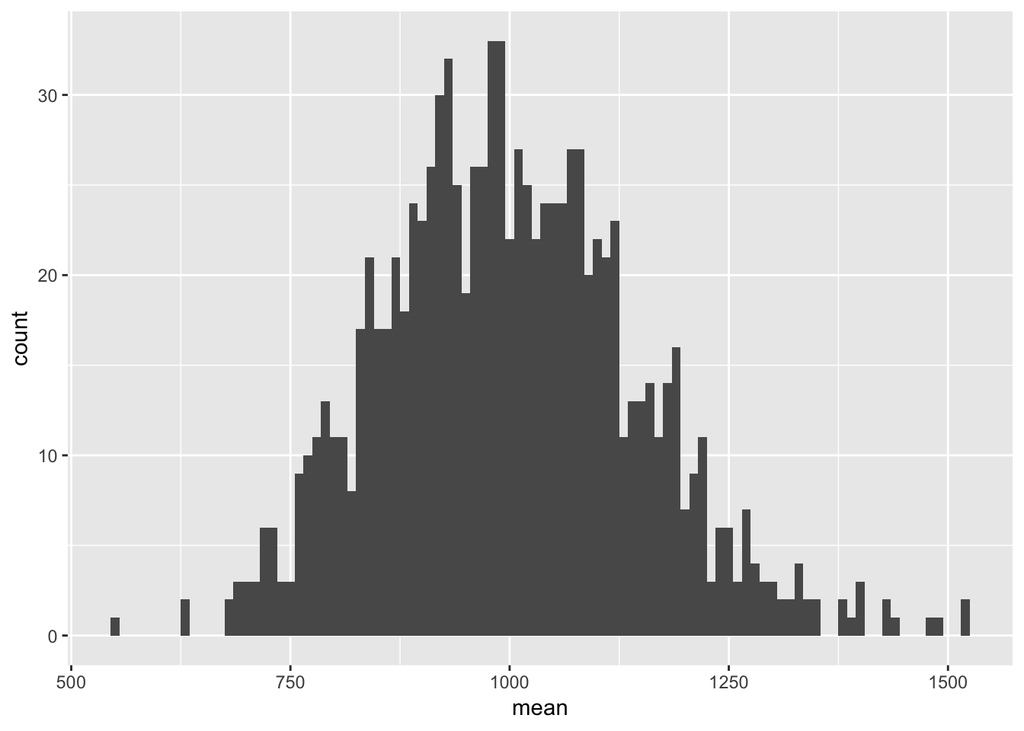

```r
mean_sd_values <- data.frame(mean = sample_means, sd = sample_sds)

# plot your sample means as a histogram
ggplot(data = mean_sd_values, mapping = aes(x = mean)) +
  geom_histogram(binwidth = 10)
```

```r
# output the standard deviation of your sample means
sd(mean_sd_values$mean)
```

```
## [1] 145.2299
```

```r
# calculate the theoretical standard error (σ=10000, n = sample size)
10000/sqrt(samp_size)
```

```
## [1] 1414.214
```

```r
# calculate the mean of the sample standard deviations and use this to calculate the empirical standard error
mean_sample_sds <- mean(mean_sd_values$sd)
mean_sample_sds/sqrt(samp_size)
```

```
## [1] 138.6851
```

**STEP 4**

Repeat **STEP 2** and **STEP 3** using a sample size of `5000`.

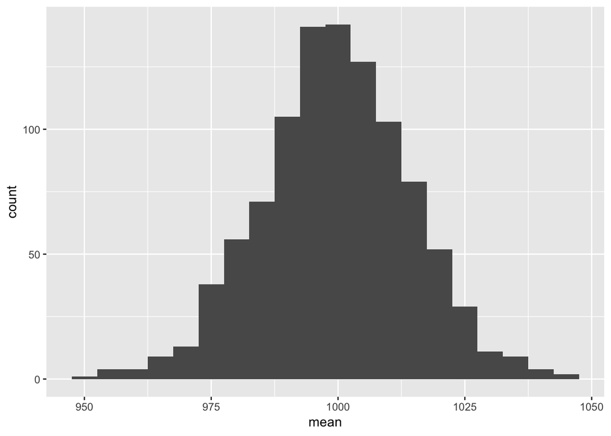

```r
samp_size <- 5000
samp_rate <- 1/1000
sample_means <- sample_sds <- c()

for (i in 1:iterations) {
  stats <- samp_fun(samp_size, samp_rate)
  sample_means[i] <- stats$samp_avg
  sample_sds[i] <- stats$samp_std_dev
}

mean_sd_values <- data.frame(mean = sample_means, sd = sample_sds)
ggplot(data = mean_sd_values, mapping = aes(x = mean)) +
  geom_histogram(binwidth = 5)
```

```r
# output the standard deviation of your sample means
sd(mean_sd_values$mean)
```

```
## [1] 14.62076
```

```r
# calculate the theoretical standard error (σ=10000, n = sample size)
10000/sqrt(samp_size)
```

```
## [1] 141.4214
```

```r
# calculate the mean of the sample standard deviations and use this to calculate the empirical standard error
mean_sample_sds <- mean(mean_sd_values$sd)
mean_sample_sds/sqrt(samp_size)
```

```
## [1] 14.136
```

# Exercise 2 - Linear Regression

Load the `train.csv` dataset into R and fit a regression model with:

- `y = SalePrice`
- Features: `LotArea`, `OverallQual`, and `ExterQual`

Answer these questions:

- Use the broom package to output the coefficients and the R-squared
- Interpret the coefficient on `LotArea`
- Interpret the coefficient on `ExterQualGd`
- Compare this model to the model we fit in HW 7 with `GrLivArea`, `OverallQual`, `Neighborhood`. Which is the better fitting model?

```r
training_data <- read_csv('/Users/svalleru/Desktop/UCB/COMPSCIX415.2-003 - Intro to DS/compscix-415-2-assignments/session9/train.csv')
model <- lm(formula = SalePrice ~ LotArea + OverallQual + ExterQual, data = training_data)
```

- Use the broom package to output the coefficients and the R-squared

```r
tidy(model)
```

```
## # A tibble: 6 x 5
##   term         estimate std.error statistic   p.value
##   <chr>           <dbl>     <dbl>     <dbl>     <dbl>
## 1 (Intercept)  40764.   12358.         3.30 9.95e-  4
## 2 LotArea          1.45     0.116     12.5  3.72e- 34
## 3 OverallQual  34466.    1216.        28.3  4.77e-141
## 4 ExterQualFa -95352.   14592.        -6.53 8.80e- 11
## 5 ExterQualGd -71529.    6737.       -10.6  2.05e- 25
## 6 ExterQualTA -97527.    7541.       -12.9  2.72e- 36
```

```r
glance(model)
```

```
## # A tibble: 1 x 11
##   r.squared adj.r.squared  sigma statistic p.value    df  logLik    AIC
##       <dbl>         <dbl>  <dbl>     <dbl>   <dbl> <int>   <dbl>  <dbl>
## 1     0.695         0.694 43948.      663.       0     6 -17677. 35368.
## # … with 3 more variables: BIC <dbl>, deviance <dbl>, df.residual <int>
```

- Interpret the coefficient on `LotArea`

When all other features are constant, 1 unit increase in `LotArea` increases `SalePrice` by $1.45

- Interpret the coefficient on `ExterQualGd`

When all other features are constant, `SalePrice` for houses with `ExterQualGd`(Good exterior material quality) are on average $71,529.49 lower than the houses with `ExterQualEx`(Excellent exteriot material quality)

- Compare this model to the model we fit in HW 7 with `GrLivArea`, `OverallQual`, `Neighborhood`. Which is the better fitting model?

Adjusted R-squared for this model is `0.694` which is lower than that of the model from HW7(`0.787`), so, HW7 model is a better fitting model

# Exercise 3 - AB Testing

Download the `ab_test_data.csv` file from Canvas. This file contains two columns: `version` and `conversion`. Each row is a visitor to a webpage. The `version` column tells us which version of the webpage the visitor saw, and the `conversion` column is a binary value and equals `1` if the visitor converted (`0` otherwise).

We want to perform an AB test on this data to see if the conversion rates are different for the two versions of the webpage.

Answer these questions:

- What proportion of visitors converted for each version of the webpage?
- Perform the AB test in R. What is the p-value for the AB test (hypothesis test of proportions)?

What proportion of visitors converted for each version of the webpage?

```r
ab_test_data <- read_csv('/Users/svalleru/Desktop/UCB/COMPSCIX415.2-003 - Intro to DS/compscix-415-2-assignments/session9/ab_test_data.csv')
conversion_stats <-
  ab_test_data %>%
  group_by(version) %>%
  summarise(
    tatal_visited = n(),
    total_converged = sum(conversion),
    propotion = total_converged/tatal_visited)

conversion_stats
```

```
## # A tibble: 2 x 4
##   version tatal_visited total_converged propotion
##   <chr>           <int>           <dbl>     <dbl>
## 1 A                2000              83    0.0415
## 2 B                2000             200    0.1
```

Version A: 4.15%

Version B: 10%

Perform the AB test in R. What is the p-value for the AB test (hypothesis test of proportions)?

```r
prop_test <- prop.test(conversion_stats$total_converged, conversion_stats$tatal_visited)
prop_test$p.value
```

```
## [1] 8.479709e-13
```

p-value is way less than alpha(0.05), so, we can reject the default null hypothesis i.e., both versions have same conversion rate. In other words, conversion rates for both versions are significantly different from each other.